# Psychometric analyses of the FAI Scale

Step 1: Descriptive statistics

[Corrado Caudek](https://ccaudek.github.io/)

First version 2019-12-17. Last modified 2019-12-17

# 1 Step 1: Descriptives

Response frequencies and item statistics are examined to assess whether items show sufficient variation to be able to differentiate respondents on the construct(s) investigated, and if there are any out-of-range values (data entry errors). Differences in response frequencies also provide a first hint regarding variation in item intensity/difficulty (and help interpret any later differences between IRT and FA results).

Associations between items are examined to identify any negative correlations (and reverse code such items for next analyses).

Plotting of multivariate outliers helps identify any respondents with idiosyncratic response patterns, which can be further investigated and either excluded (e.g. if errors are identified in the data collection/entry) or kept within the sample (if there are no valid reasons for exclusion).

```r
mydata2 <- mydata[, -((1:n_items)[bad_item])]
```

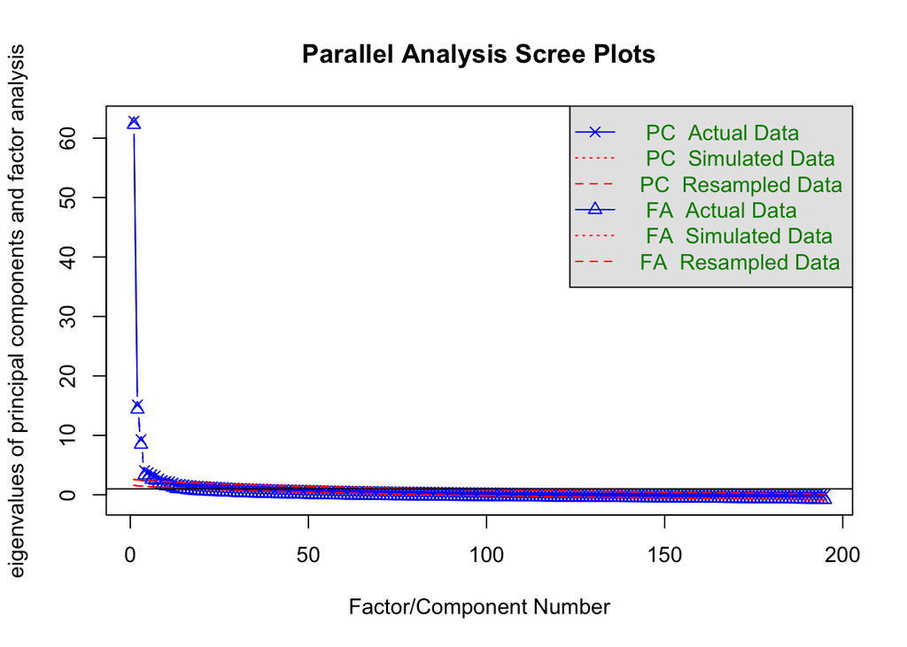

```
## Parallel analysis suggests that the number of factors =  12  and the number of components =  10
```

```r
fa.parallel(mydata2)
```

```r
R <- cor(mydata2)

fa_out <- principal(R, nfactors = 12, n.obs = n_subj, rotate = "promax")
print(fa_out$loadings[, 1], cutoff = 0.4)
```

```
##           i1           i2           i3           i4           i5           i6
##  0.045800165  0.081600210  0.573592318  0.736052830  0.151269577  0.228216490
##           i7           i8           i9          i10          i11          i12
##  0.430766244  0.708558576  0.481755958  0.692872507  0.187108498  0.244049342
##          i13          i14          i15          i16          i17          i18
## -0.098976285  0.283015834  0.115601989  0.645154827  0.673334617 -0.029863680
##          i19          i20          i21          i22          i23          i24
##  0.215271426 -0.030181877  0.124333674  0.731376415  0.767486815 -0.038729597
##          i25          i26          i27          i28          i29          i30
##  0.314654493  0.710312736  0.753223592  0.090979868  0.076174950  0.312798872
##          i31          i32          i33          i34          i35          i36
##  0.249088775  0.027904119  0.156671392  0.808048367  0.625090058  0.066843961
##          i37          i38          i39          i40          i41          i42
##  0.142545994 -0.121056097  0.090095851  0.544378999  0.906732985  0.869464738
##          i43          i44          i45          i46          i47          i48
##  0.548009396 -0.099085799  0.019388898 -0.099621976  0.119841702 -0.045573124
##          i49          i50          i51          i52          i53          i54
## -0.136615440  0.054911345  0.066504030  0.117818928  0.027340848  0.145729329
##          i55          i56          i57          i58          i59          i60
##  0.789430907  0.813487037  0.176556537 -0.030544309  0.700429729 -0.173462398
##          i61          i62          i63          i64          i65          i66
##  0.008335399  0.690019721  0.073042775  0.265092100  0.781121362  0.594298945
##          i67          i68          i69          i70          i71          i72
##  0.661856616  0.403061787  0.619312014  0.745061384  0.092240516  0.134058497
##          i73          i74          i75          i76          i78          i79
##  0.081044934 -0.165539136  0.791055232 -0.106527850 -0.091150434  0.551623080
##          i80          i81          i82          i83          i84          i85
##  0.657824652  0.280108810  0.328263846 -0.337172817  0.691101503  0.667571815
##          i86          i87          i88          i89          i90          i91
##  0.315646721  0.066092930  0.488919900  0.048257550  0.687203407  0.022827738
##          i92          i93          i94          i95          i96          i97
##  0.612864522  0.807609739  0.686191762  0.686158558  0.188555539  0.055521375
##          i98          i99         i100         i101         i102         i103
##  0.093611890  0.425193888 -0.146120715  0.153943051  0.674206386  0.208015944
##         i104         i105         i106         i107         i108         i109
##  0.777282898  0.022392681 -0.130531662  0.323202712  0.756379161 -0.077189833
##         i110         i111         i112         i113         i114         i115
## -0.037906535  0.255240928 -0.005563481  0.325096421 -0.026523395  0.642917062
##         i116         i117         i118         i119         i120         i121
## -0.330795942  0.789116401  0.674185849  0.807333966  0.487930580  0.069512062
```

[output cut: 11 more lines]

```
## -0.005738105  0.254105401  0.097163834  0.604707572  0.514844692  0.111681255
##         i158         i159         i160         i161         i162         i163
## -0.051344827 -0.082929213  0.692034670  0.602731149 -0.242727731  0.523126362
##         i164         i165         i166         i167         i168         i169
##  0.567658882  0.505572104  0.744031809  0.666785433 -0.023051936  0.006392560
##         i170         i171         i172         i173         i174         i175
##  0.568684042  0.672452883  0.671962435  0.162580401  0.083100305 -0.034101750
##         i176         i177         i178         i179         i180         i181
##  0.060152438  0.703813695  0.007731539  0.696904576  0.528935591  0.065394690
##         i183         i184         i185         i186         i187         i188
##  0.602251274 -0.167432428  0.360401816  0.025456649  0.251010615  0.757708706
##         i189         i190         i191         i192         i193         i194
##  0.577450849  0.024479088  0.233047702  0.564700928 -0.076522863  0.590133325
##         i195         i196         i197
##  0.593287069  0.164981182 -0.093200159
```

```r
f1_items <- names(
  (fa_out$loadings[, 1] )[fa_out$loadings[, 1] > 0.4]
)
```

```r
n_factors <- 12
item_list <- list()

for (i in 1:n_factors) {
  item_list[[i]] <- names((fa_out$loadings[, i])[fa_out$loadings[, i] > 0.4])
}
```

## 1.1 Second factor

```r
im <- mydata2[, item_list[[2]]]
```

```r
d2mydata <- outlier(im, cex=.6, bad=3)
```

[figure not shown]

## 1.2 Interpretation

- Are there any out-of-range values?
- Are all response options well-represented in the data?
- Are all associations between items positive?
- Are there multivariate outliers in the data?

# 2 Step 2: Item properties - Mokken Scaling Analysis (MSA)

Idiosyncratic response patterns are examined within MSA as number of Guttman errors and displayed graphically. Coefficients of homogeneity (H) are examined for the original item set (for each item, item pair, and the overall scale) Values >=.30 indicate scalability.

An Automated Item Selection Procedure (*aisp*) is performed at increasing threshold levels of homogeneity (c) to examine dimensionality. If all items show up as belonging to dimension number 1, this means that the scale is unidimensional at that threshold of homogeneity (indicated in column headings, from .05 to .80). The minimum threshold for homogeneity is .30. Items with a value of 0 are unscalable at that threshold. If at higher threshold levels item separate from dimension number 1 in groups (e.g. 2 or more items ‘leave’ dimension 1 at the same threshold) this indicates that those items may represent a separate dimension. If, on the contrary, items ‘leave’ the dimension one by one and become unscalable, this indicates that there is a single dimension with which items are more or less strongly associated. Unidimensional item subsets are selected based on the *aisp* algorithm (the items selected should show unidimensionality at a threshold level of .30 or higher) and theoretical considerations.

These item subsets are then tested for local independence, monotonicity, and invariant item ordering - 3 criteria for model fit in MSA.

- Local independence is reported as TRUE/FALSE values; if all values are TRUE, the items show local independence with default parameters; if any of the items show up as FALSE, more investigation is needed.
- Monotonicity is shown in table format (default minsize). The ‘zsig’ column shows the number of statistically-significant violations of monotonicity per item; if this number is >0 for one or more items, more investigation of monotonicity is needed (for more testing, various minsize values can be specified in separate tests). Monotonicity is also displayed visually by item step response functions (ISRF; minsize values can be modified to provide a sufficient number of rest score groups for adequate testing).
- invariant item ordering test are shown first in table format (default minsize). The ‘tsig’ column shows the number of statistically-significant violations of IIO per item; if any of the items do not show 0 in the #tsig column, more investigation of IIO is needed (for more testing, various minsize values can be specified in separate tests). IIO is also displayed visually by ISRF plots for each item pair (as above, minsize values can be modified to provide a sufficient number of rest score groups for adequate testing).

For item sets that fit these criteria, it can be concluded that items measure the same construct and total scores can be used to locate respondents on the unidimensional continuum that represent the construct.

## 2.1 Results

The frequencies of endorsing individual response options are presented in Table 1, and barplots of item score distributions are shown in Figure 1.

Multivariate outliers in the item set (Mahalanobis distance - D<sup>2</sup> values) are displayed graphically in Figure 4.

Table 1: Frequencies of item response options

| Item label | YESPercentage |
| --- | --- |
| i61 | 0.00% |
| i76 | 0.00% |
| i152 | 0.00% |
| i32 | 0.20% |
| i77 | 0.20% |
| i117 | 0.20% |
| i121 | 0.20% |
| i157 | 0.20% |
| i182 | 0.20% |
| i53 | 0.41% |
| i57 | 0.41% |
| i58 | 0.41% |
| i75 | 0.41% |
| i78 | 0.41% |
| i80 | 0.41% |
| i110 | 0.41% |
| i138 | 0.41% |
| i174 | 0.41% |
| i12 | 0.61% |
| i24 | 0.61% |
| i71 | 0.61% |
| i72 | 0.61% |
| i89 | 0.61% |
| i109 | 0.61% |
| i153 | 0.61% |
| i175 | 0.61% |
| i193 | 0.61% |
| i197 | 0.61% |
| i1 | 0.81% |
| i21 | 0.81% |

[output cut: 167 more lines]

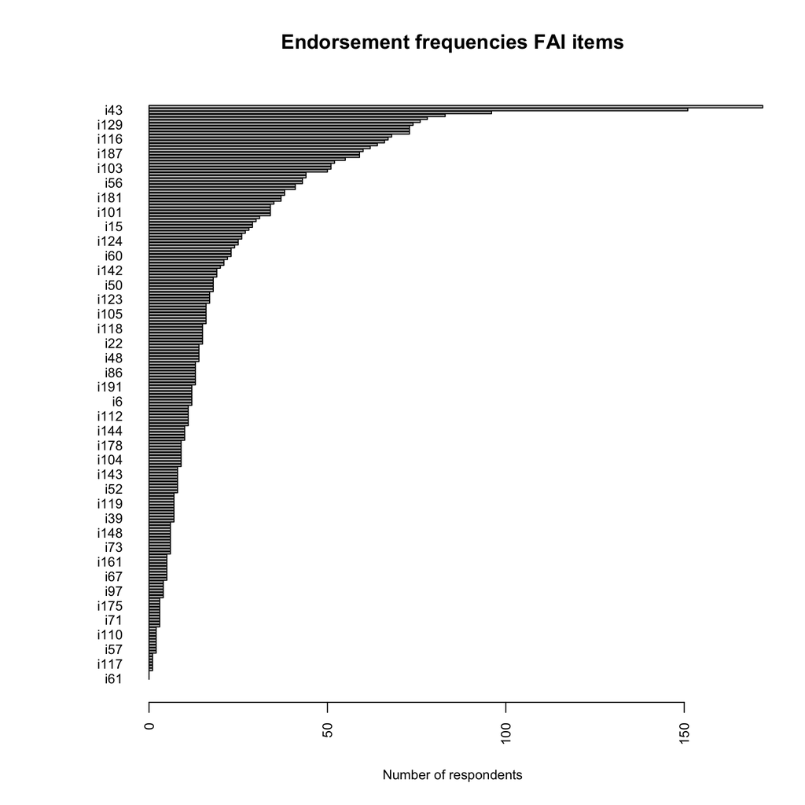

Figure 1: Barplots of high score frequencies

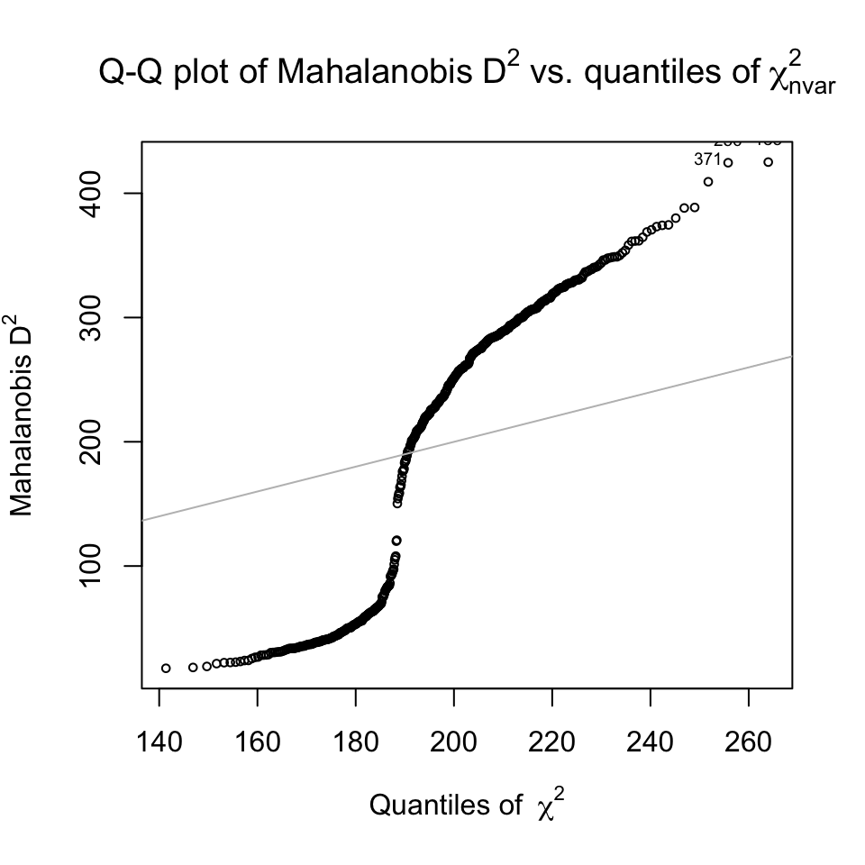

Figure 4: Multivariate outliers in item set

There were 182 respondents with D<sup>2</sup> values with probability values <.001 (considering a chi-squared distribution with df = the number of items). The maximum D<sup>2</sup> value is 425.09.